# An Introduction to Options and Risk Margining

Dublin Data Science

Mick Cooney mickcooney@gmail.com

2019-03-25

# Introduction

## Derivatives

[figure not shown]

*If you intelligently trade derivatives, it’s like a license to steal*

```
Charlie Munger, Berkshire Hathaway (2014)
```

## Options

The contract offers the buyer the right, but not the obligation, to trade (buy or sell) the underlying asset at a specific price during a defined period of time or on a specific date.

Options on everything

Equities

Futures

Bonds

Swaps

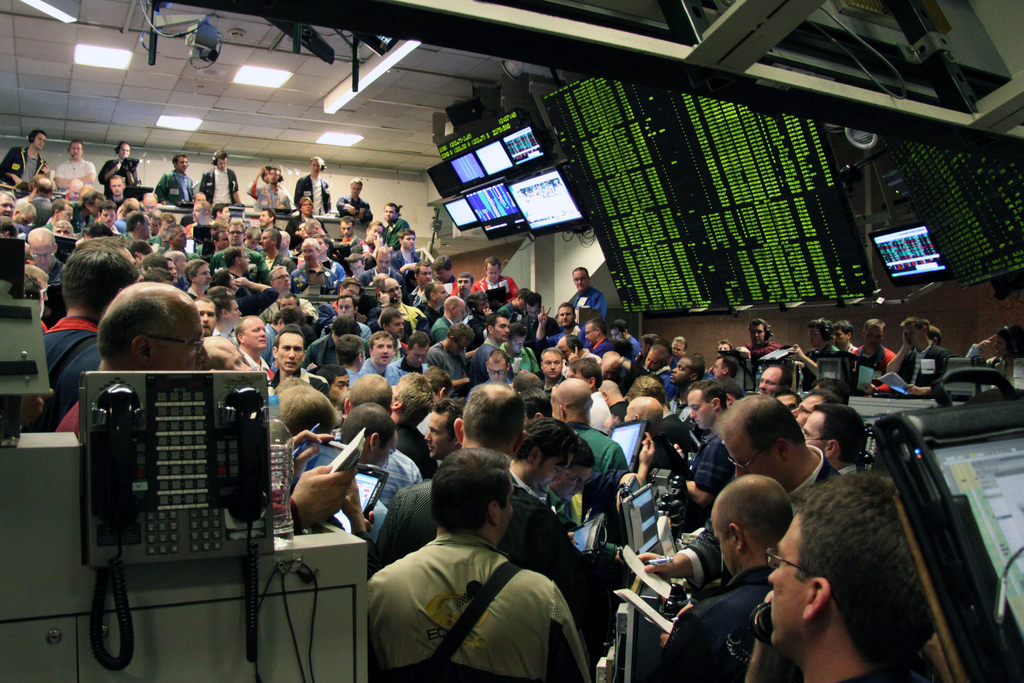

[figure not shown]

# Options Trading

## Terminology

Call/Put

Long/Short

Strike

Expiration / Lifetime

American / European

## Risk

Counterparty

Liquidity

Asset

## Exchanges

Central marketplace

Fixed expirations and strikes

Contracts for 100 shares

Two-sided open outcry

*bid-ask spread*

Proxy for liquidity

# Payoffs and Option Spreads

Payoff, value of option at expiration

$S$, Price of underlying

$K$, Strike price in contract

## Payoff Graphs

Plot of payoff vs underlying

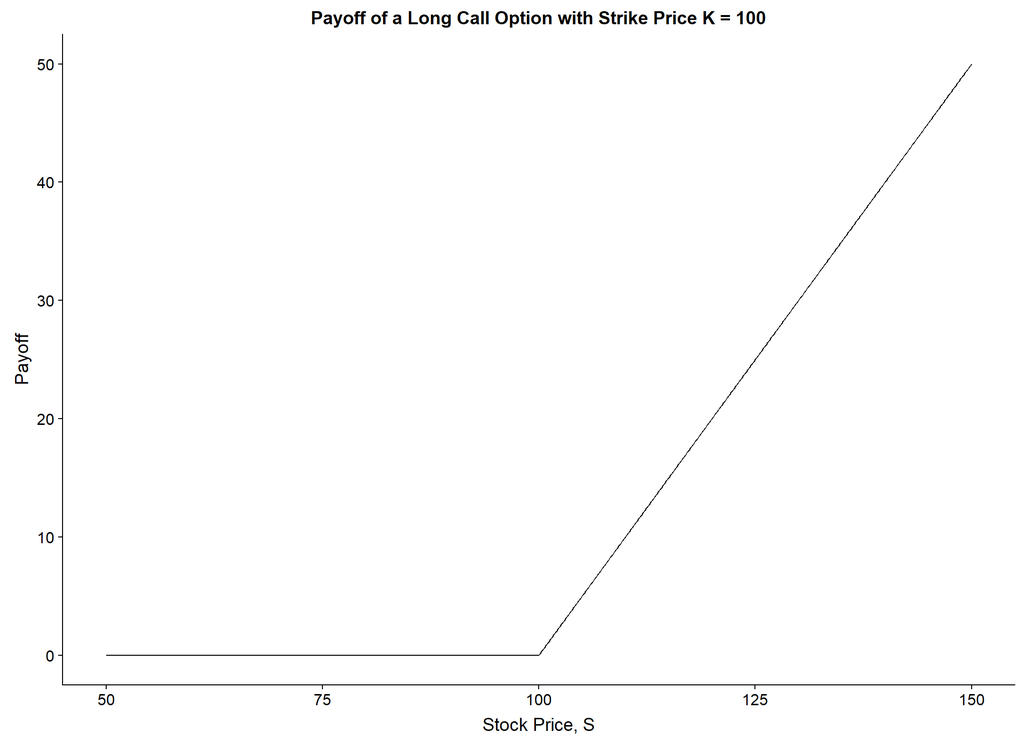

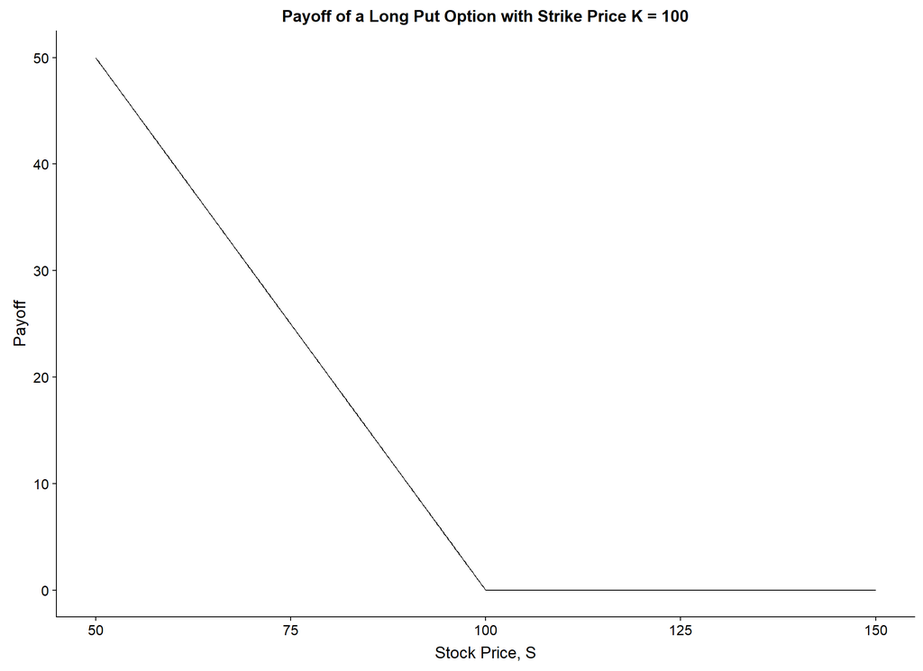

## Option Spreads

Options often combined into *spreads*

### Bullish Call Spread

Same expiry

Long call at strike $K_1$

Short call at strike $K_2$

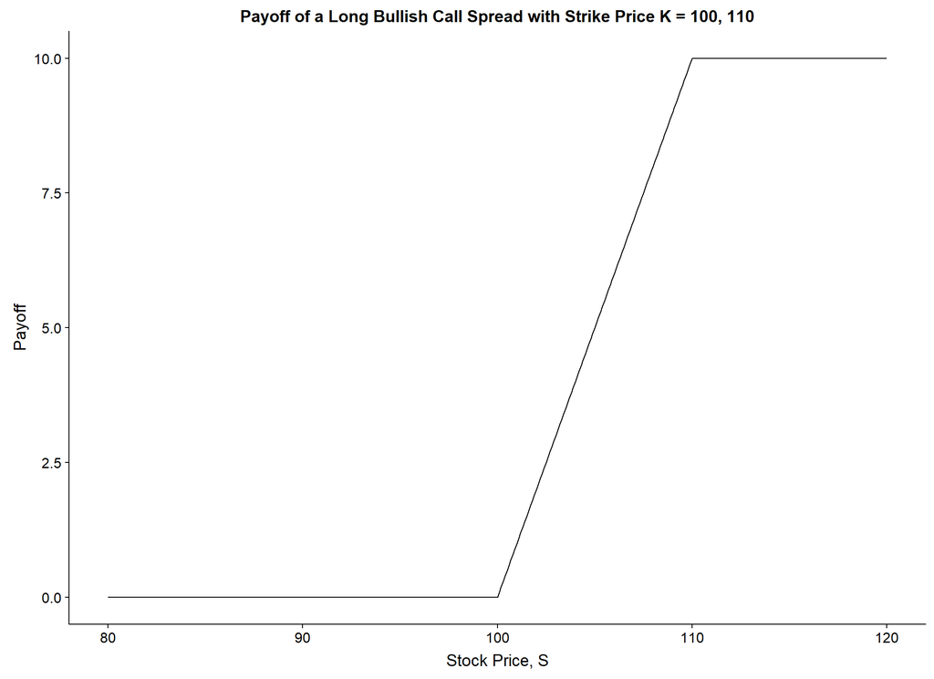

### Long Straddle

Same expiry

Long call and put at strike $K$

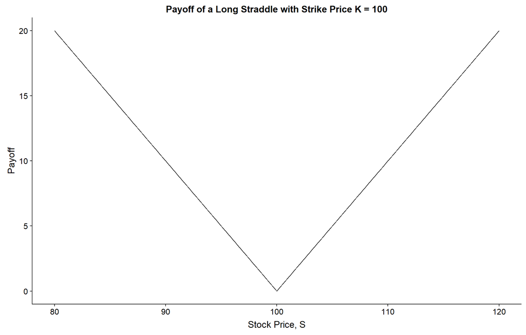

Same expiry

Long calls at $K_1$, $K_3$

Short two calls at $K_2$

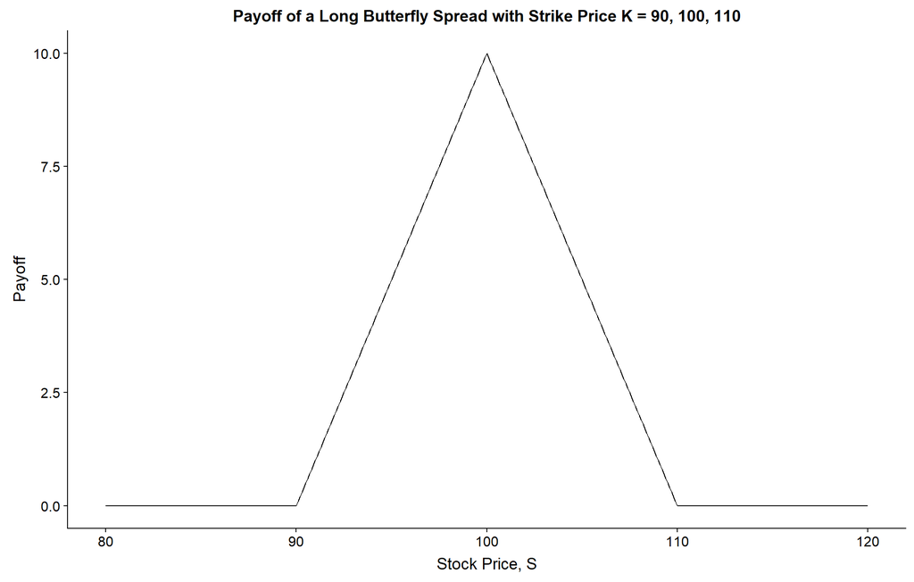

### Others

Calendar spreads

Box Spreads

Condor

Conversion / Reversal

Focus on value at expiration

What about while ‘in-force’

# Option Pricing

How do we price/value this ‘insurance’?

What impacts this value?

## Key Assumption of Finance

“No arbitrage” condition

No risk-free profit

## Black Scholes

$$\begin{eqnarray*}
S &=& \text{current price of underlying} \\
K &=& \text{strike price of contract} \\
t &=& \text{time to expiration} \\
r &=& \text{risk-free interest rate} \\
\sigma &=& \text{volatility of underlying} \\
\end{eqnarray*}$$

$$\frac{dV}{dt} + \frac{1}{2} \sigma^2 S^2 \frac{d^2 V}{dS^2} + rS \frac{dV}{dS} - rV = 0$$

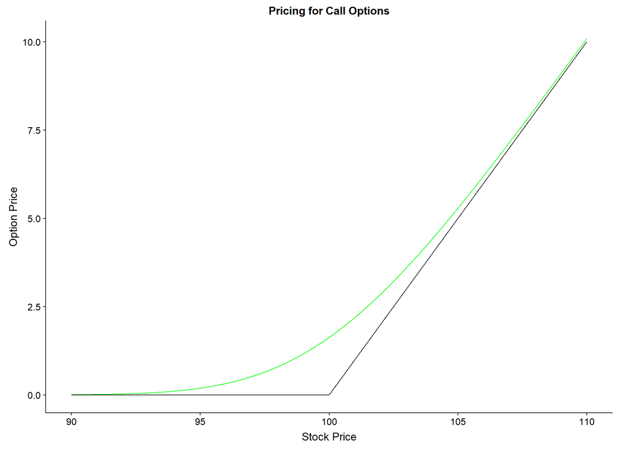

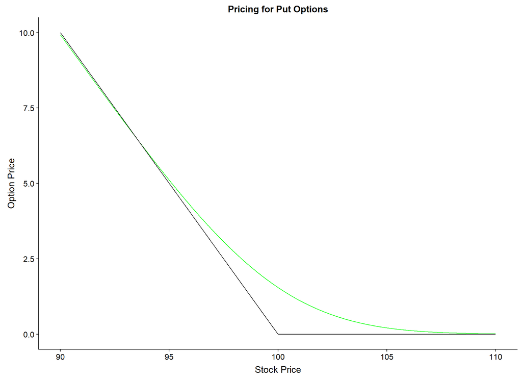

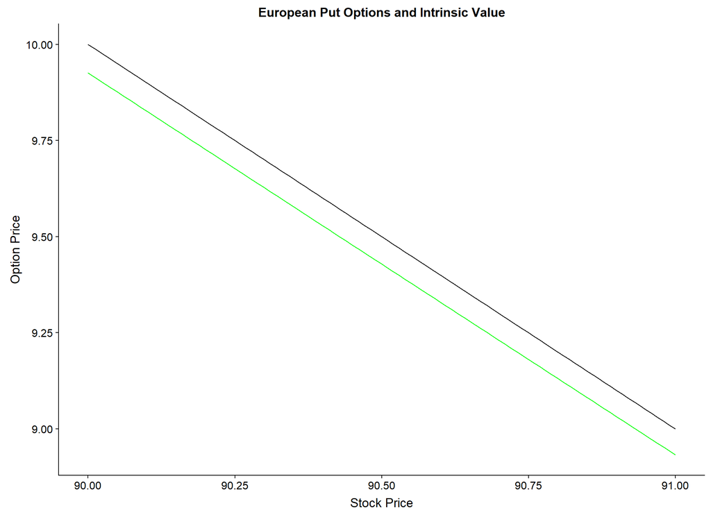

$$\text{Price} = \text{Intrinsic} + \text{Time}$$

Time value aka ‘Premium’

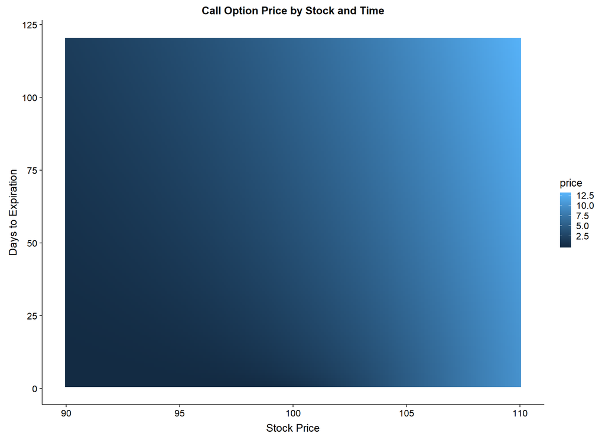

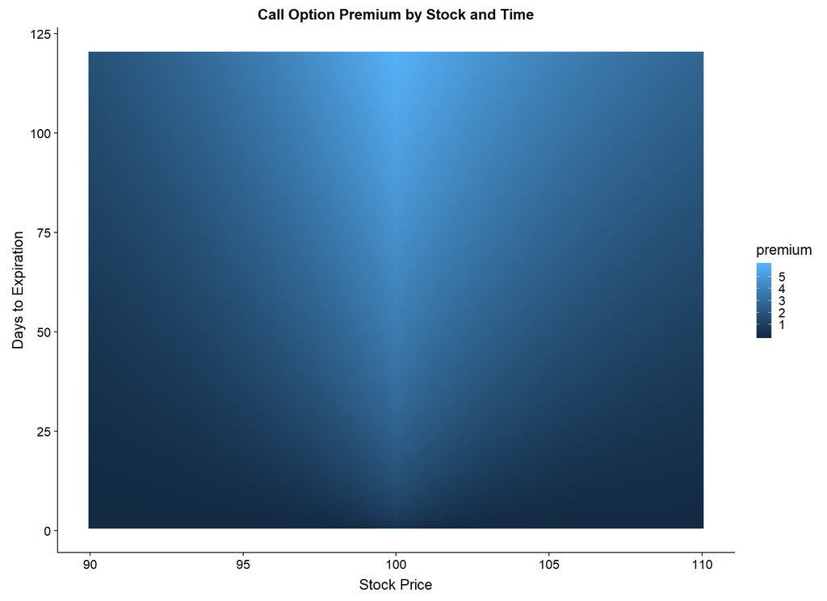

## Greeks

“Sensitivities” of price to inputs

Crucial for risk management

### Delta, $\frac{dV}{dS}$

‘Share’ equivalent

Expressed in hundreds of shares

25 delta put, 70 delta call

*at the money* $\implies$ 50 delta

### Gamma, $\frac{d^2 V}{dS^2}$

Change in deltas due to price

Long options, long gamma

### Vega, $\frac{dV}{d\sigma}$

Expressed in currency

Change per vol ‘click’

Long options, long vega

### Theta, $\frac{dV}{dt}$

Expressed in currency

Option decay - daily not annual

Long options, pay theta

### Rho, $\frac{dV}{dr}$

Important for longer term options

Greeks additive within a stock

Theta additive across portfolio

More sensitivities exist

Useful, but less common

# Option Risk and Non-Linear Behaviour

Option values behave non-linearly

Non-intuitive

Risks non-obvious

## Non-Linear Behaviour

### “Leverage Effect”

$$\begin{eqnarray*}
S = 97.00, t = 2.0 &\implies& 0.03 \\
S = 99.00, t = 1.0 &\implies& 0.15 \\
S = 100.00, t = 0.5 &\implies& 0.36
\end{eqnarray*}$$

### Time Decay

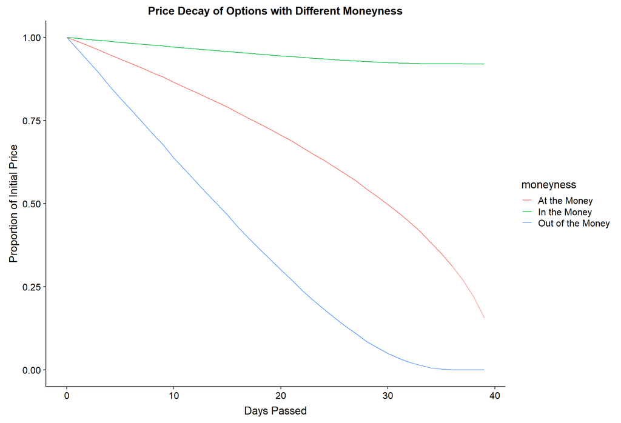

Nothing constant

All Greeks interact

Complex

How do we quantify the risk of a position?

## Margin

Covers risk of position

Probabilistic

Regulatory vs Contractual

“Margin Calls”

### Risk-based Margin

Most commonly used

Scenario-driven

1 in 20 Years

Aggregate Greek positions

Accounts for correlations

### Rules-based Margin

Canadian regulator

Margins based on spreads

“How much could you lose?”

Spread-specific calculation

Percentage of maximum loss

Suboptimal

## Example Calculations

### Long Stock

25% of value

1,000 shares of AAPL @ 200.00 USD

Total Value: 200,000.00 USD

Margin: 50,000.00 USD

### Long Call Spread

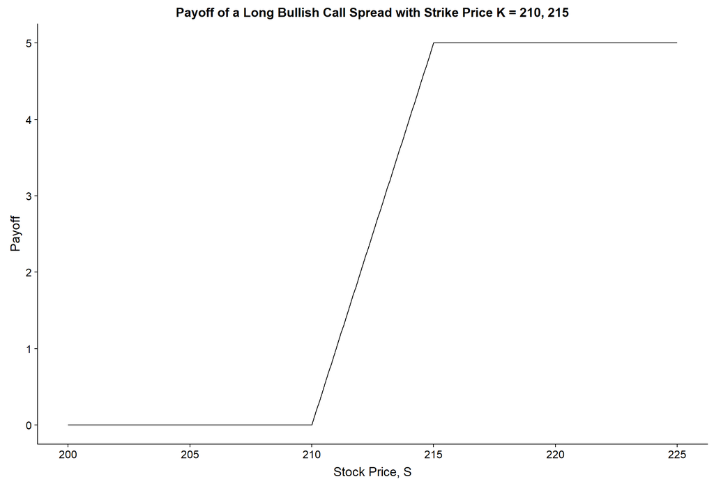

Market value of position

$$\begin{eqnarray*}
\text{Long Jun 210 Call} &\implies& \$0.50 \\
\text{Short Jun 215 Call} &\implies& \$0.30 \\
\end{eqnarray*}$$

Total Value: $(0.50 - 0.30) \times 100 \times 100 = 2,000.00$ USD

Margin: 2,000.00 USD

### Short Call Spread

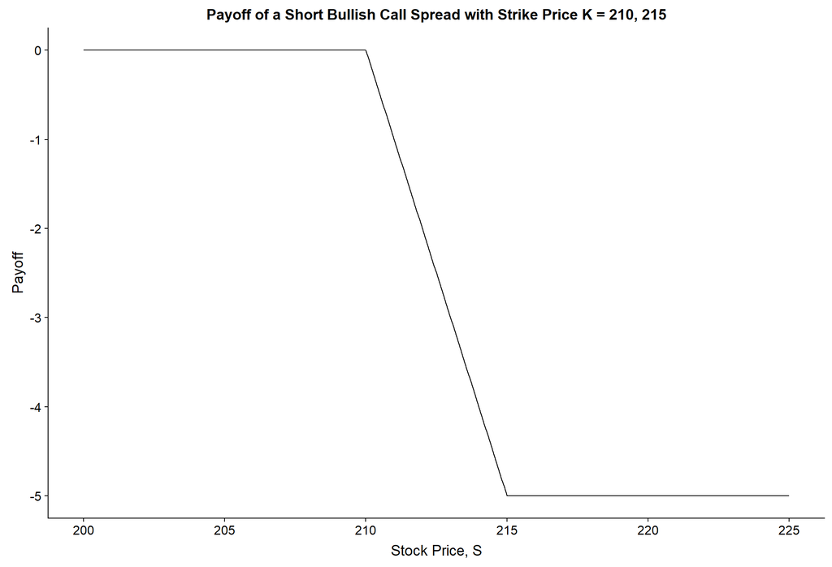

Maximum possible loss

Long Jun 210 Call - 0.50

Short Jun 215 Call - 0.30

Total Value: $(215 - 210) \times 100 \times 100 = 50,000.00$ USD

Margin: 50,000.00 USD

# Margin Calculator

## Example Option Portfolio

| symbol | expiry | strike | callput | price | position |
| --- | --- | --- | --- | --- | --- |
| XIU.TSX | 2014-06-21 | 18.50 | P | 0.075 | 3 |
| XIU.TSX | 2014-06-21 | 19.25 | C | 1.945 | 68 |
| XIU.TSX | 2014-06-21 | 19.50 | P | 0.020 | -58 |
| XIU.TSX | 2014-06-21 | 19.75 | C | 1.445 | -39 |
| XIU.TSX | 2014-06-21 | 20.00 | C | 1.215 | -54 |
| XIU.TSX | 2014-06-21 | 20.25 | C | 0.950 | -19 |
| XIU.TSX | 2014-06-21 | 20.50 | C | 0.725 | 47 |
| XIU.TSX | 2014-06-21 | 20.75 | P | 0.060 | -74 |
| XIU.TSX | 2014-06-21 | 21.00 | C | 0.270 | 24 |
| XIU.TSX | 2014-06-21 | 21.00 | P | 0.135 | 9 |
| XIU.TSX | 2014-06-21 | 21.25 | C | 0.090 | -10 |
| XIU.TSX | 2014-06-21 | 21.25 | P | 0.255 | -40 |
| XIU.TSX | 2014-06-21 | 21.50 | C | 0.050 | -46 |
| XIU.TSX | 2014-06-21 | 21.50 | P | 0.450 | -50 |
| XIU.TSX | 2014-06-21 | 21.75 | C | 0.035 | -89 |
| XIU.TSX | 2014-06-21 | 22.00 | C | 0.020 | 23 |
| XIU.TSX | 2014-06-21 | 22.00 | P | 0.930 | -4 |
| XIU.TSX | 2014-07-19 | 19.75 | P | 0.035 | 62 |
| XIU.TSX | 2014-07-19 | 20.50 | C | 0.735 | 43 |
| XIU.TSX | NA | NA | NA | 21.230 | -4000 |

### Portfolio Greeks

| nav | delta | gamma | vega | theta | rho |
| --- | --- | --- | --- | --- | --- |
| -82,906 | 5,804 | -12,827 | -291 | 41,894 | 16,544 |

Margin calculation?

Divide portfolio into spreads

Margin calculation for each spread

Total margin sum of spread margin

How do we divide up portfolio?

## Suggested Approach

1. Sample spreads
2. Calculate margin
3. Allocate whole portfolio
4. Sum amounts

| symbol | expiry | strike | callput | position |
| --- | --- | --- | --- | --- |
| XIU.TSX | 2014-06-21 | 18.50 | P | 3 |
| XIU.TSX | 2014-06-21 | 19.25 | C | 68 |
| XIU.TSX | 2014-06-21 | 19.50 | P | -58 |
| XIU.TSX | 2014-06-21 | 19.75 | C | -39 |
| XIU.TSX | 2014-06-21 | 20.00 | C | -54 |
| XIU.TSX | 2014-06-21 | 20.25 | C | -19 |
| XIU.TSX | 2014-06-21 | 20.50 | C | 47 |
| XIU.TSX | 2014-06-21 | 20.75 | P | -74 |
| XIU.TSX | 2014-06-21 | 21.00 | C | 24 |
| XIU.TSX | 2014-06-21 | 21.00 | P | 9 |
| XIU.TSX | 2014-06-21 | 21.25 | C | -10 |
| XIU.TSX | 2014-06-21 | 21.25 | P | -40 |
| XIU.TSX | 2014-06-21 | 21.50 | C | -46 |
| XIU.TSX | 2014-06-21 | 21.50 | P | -50 |
| XIU.TSX | 2014-06-21 | 21.75 | C | -89 |
| XIU.TSX | 2014-06-21 | 22.00 | C | 23 |
| XIU.TSX | 2014-06-21 | 22.00 | P | -4 |
| XIU.TSX | 2014-07-19 | 19.75 | P | 62 |
| XIU.TSX | 2014-07-19 | 20.50 | C | 43 |
| XIU.TSX | NA | NA | NA | -4000 |

| symbol | expiry | strike | callput | position |
| --- | --- | --- | --- | --- |
| XIU.TSX | 2014-06-21 | 18.50 | P | 3 |
| XIU.TSX | 2014-06-21 | 19.25 | C | 68 |
| XIU.TSX | 2014-06-21 | 19.50 | P | -58 |
| XIU.TSX | 2014-06-21 | 19.75 | C | -39 |
| XIU.TSX | 2014-06-21 | 20.00 | C | -54 |
| XIU.TSX | 2014-06-21 | 20.25 | C | -19 |
| XIU.TSX | 2014-06-21 | 20.50 | C | 47 |
| XIU.TSX | 2014-06-21 | 20.75 | P | -74 |
| XIU.TSX | 2014-06-21 | 21.00 | C | 24 |
| XIU.TSX | 2014-06-21 | 21.00 | P | 9 |
| XIU.TSX | 2014-06-21 | 21.25 | C | -10 |
| XIU.TSX | 2014-06-21 | 21.25 | P | -40 |
| XIU.TSX | 2014-06-21 | 21.50 | C | -46 |
| XIU.TSX | 2014-06-21 | 21.50 | P | -50 |
| XIU.TSX | 2014-06-21 | 21.75 | C | -89 |
| XIU.TSX | 2014-06-21 | 22.00 | C | 23 |
| XIU.TSX | 2014-06-21 | 22.00 | P | -4 |
| XIU.TSX | 2014-07-19 | 19.75 | P | 62 |
| XIU.TSX | 2014-07-19 | 20.50 | C | 43 |
| XIU.TSX | NA | NA | NA | -4000 |

| symbol | expiry | strike | callput | position |
| --- | --- | --- | --- | --- |
| XIU.TSX | 2014-06-21 | 18.50 | P | 3 |
| XIU.TSX | 2014-06-21 | 19.25 | C | 68 |
| XIU.TSX | 2014-06-21 | 19.50 | P | -58 |
| XIU.TSX | 2014-06-21 | 19.75 | C | -39 |
| XIU.TSX | 2014-06-21 | 20.00 | C | -54 |
| XIU.TSX | 2014-06-21 | 20.25 | C | -19 |
| XIU.TSX | 2014-06-21 | 20.50 | C | 47 |
| XIU.TSX | 2014-06-21 | 20.75 | P | -74 |
| XIU.TSX | 2014-06-21 | 21.00 | C | 24 |
| XIU.TSX | 2014-06-21 | 21.00 | P | 9 |
| XIU.TSX | 2014-06-21 | 21.25 | C | -10 |
| XIU.TSX | 2014-06-21 | 21.25 | P | -40 |
| XIU.TSX | 2014-06-21 | 21.50 | P | -4 |
| XIU.TSX | 2014-06-21 | 21.75 | C | -89 |
| XIU.TSX | 2014-06-21 | 22.00 | C | 23 |
| XIU.TSX | 2014-06-21 | 22.00 | P | -4 |
| XIU.TSX | 2014-07-19 | 19.75 | P | 62 |
| XIU.TSX | 2014-07-19 | 20.50 | C | 43 |
| XIU.TSX | NA | NA | NA | -4000 |

## Distribution of Total Margin

```
## $spread
## [1] "unhedged.short.option"
##
## $asset.dt
##      asset.symbol  symbol asset.type contract.size     expiry strike callput
## 1 XIU140621C21.75 XIU.TSX     option           100 2014-06-21  21.75       C
##   underlying price margin.perc position money
## 1      21.23 0.035        0.25      -89 -0.52
##
## $margin
## [1] 42608.8
```

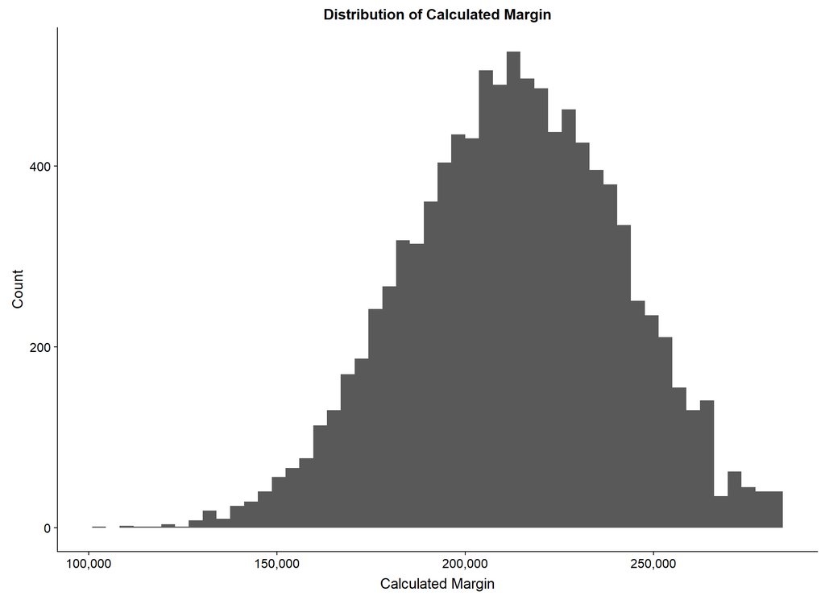

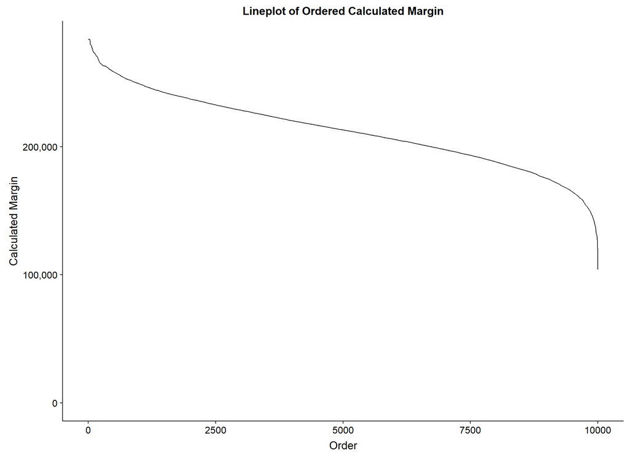

| sim_id | comp_id | spread | margin | total_margin |
| --- | --- | --- | --- | --- |
| 498 | 6 | short.call.short.put.spread | 20699.25 | 104081 |
| 498 | 13 | short.call.short.put.spread | 15448.00 | 104081 |
| 498 | 15 | covered.put | 15391.75 | 104081 |
| 498 | 9 | short.call.short.put.spread | 12738.00 | 104081 |
| 498 | 11 | short.call.short.put.spread | 9067.50 | 104081 |
| 498 | 16 | unhedged.short.option | 6702.50 | 104081 |
| 498 | 14 | covered.put | 5838.25 | 104081 |
| 498 | 17 | unhedged.short.option | 5838.25 | 104081 |
| 498 | 2 | callput.spread | 3942.00 | 104081 |
| 498 | 5 | callput.spread | 3010.00 | 104081 |
| 498 | 8 | unhedged.long.option | 2772.00 | 104081 |
| 498 | 4 | callput.spread | 1890.00 | 104081 |
| 498 | 3 | callput.spread | 475.00 | 104081 |
| 498 | 1 | unhedged.long.option | 121.50 | 104081 |
| 498 | 10 | callput.spread | 87.00 | 104081 |
| 498 | 7 | unhedged.long.option | 46.00 | 104081 |
| 498 | 12 | unhedged.long.option | 14.00 | 104081 |

# Wrap-up and Summary

## Weaknesses

Undirected exploration

Memory intensive

## Further Work

Improve optimisation

Discrete state exploration

Engineering and Physics?

## Real-world Relevance

Purely academic interest?

Linearity intuitive

Linear approximations appealing

HOWEVER

Risk usually non-linear

Non-zero second derivative

Bacterial growth question

Not always quantifiable

*If we can’t measure what is important, we make what we can measure important*

```
    - 'The Vietnam War' Documentary Series
```

## Further Reading

### Blogpost Series

https://blog.applied.ai/a-practical-introduction-to-options-part-1/

https://blog.applied.ai/a-practical-introduction-to-options-part-2/

https://blog.applied.ai/a-practical-introduction-to-options-part-3/

https://blog.applied.ai/a-practical-introduction-to-options-part-4/

### Margin Calculator

http://www.github.com/kaybenleroll/options_margin_calculator

### Options Trading Flowchart

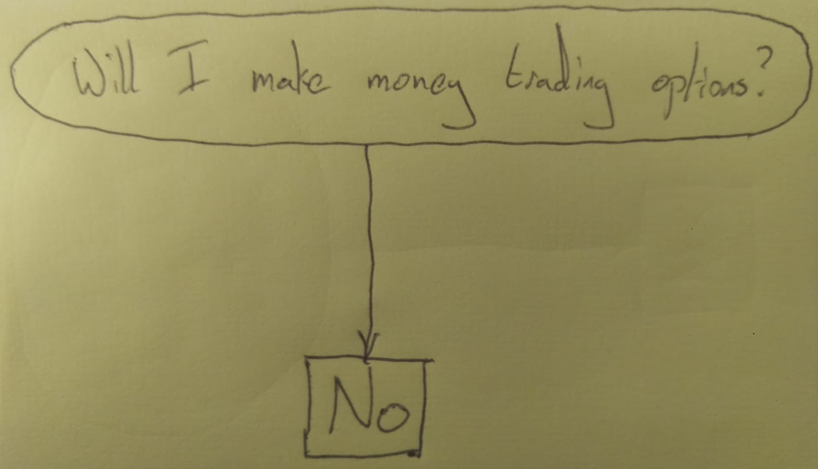

## Questions?

http://www.github.com/kaybenleroll/data_workshops

mickcooney@gmail.com